# The Little Typer.Friedman2018

**with either an even or an odd number of friends.**

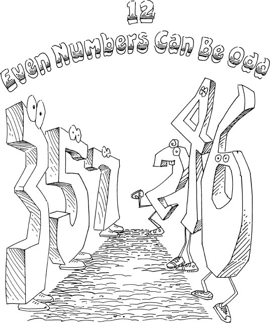

What is an even number?

<sup>1</sup>

It is a number that can be split into two equal halves.

What does it mean for a number to be split into two equal halves?

<sup>2</sup>

It means that,

“There is some number that, added to itself, yields the original number.”

How can that definition be written as a type?

<sup>3</sup>

According to frame 10:18, a Σ-expression does the trick.

A “there is” statement has two important parts: the type of the thing that exists, and a property that it has.

Here, the type of thing that exists is Nat, and its property is being half of the even Nat. These are the respective **car** and **cdr** of the evidence for a “there is” statement.

<sup>4</sup>

What does **Even** look like?

The definition of evenness can be written as a function that returns a type.

(**claim *Even***

(→ Nat

*U*))

(**define *Even***

(λ (*n*)

(Σ ((*half* Nat))

(**=** Nat *n* (**double** half)))))

What is the value of (**Even** 10)?

<sup>5</sup>

The value of

(**Even** 10)

is

(Σ ((*half* Nat))

(**=** Nat 10 (**double** half))).

What are the values in (**Even** 10)?

<sup>6</sup>

The values look like (cons *a d*), where

*a*

is a Nat and

*d*

is an

(**=** Nat 10 (**double** a)).

Find *a* and *d* so that

(cons *a d*)

is an

(**Even** 10).

<sup>7</sup>

*a* is clearly 5 because 5 is half of 10.

And

(same 10)

is an

(**=** Nat 10 (**double** 5)).

This is what is needed to prove that 10 is even.

What is the proof?

<sup>8</sup>

The proof is

(cons 5

(same 10)).

That’s right. What about 0?

<sup>9</sup>

Half of 0 is 0.

(**claim *zero-is-even***

(**Even** 0))

(**define *zero-is-even***

(cons 0

(same 0)))

What is another way that **Even** could have been defined?

<sup>10</sup>

Wouldn’t **+** do the trick?

(**define *Even***

(λ (*n*)

(Σ ((*half* Nat))

(**=** Nat *n* (**+** *half half*)))))

That would certainly work, because

“For all *n*, (**twice** n) equals (**double** n).”

Although two functions always return the same answer, sometimes one of them is easier to use because it more quickly becomes a value. In particular, **+** and thus **twice** leave an add1 on the second argument, while **double** puts both add1s at the top immediately.

<sup>11</sup>

As seen in the proof of **twice=double** in frame 9:52.

How can the statement,

“Two greater than every even number is even.”

be written as a type?

<sup>12</sup>

Good question.

It can be useful to use more descriptive prose when translating a statement into a type.

Here’s another way to say the same thing:

“For every natural number *n*, if *n* is even, then 2 + *n* is even.”

<sup>13</sup>

“Every” sounds like Π.

(**claim +*two-even***

(Π ((*n* Nat))

(→ (**Even** n)

(**Even** (**+** 2 *n*)))))

Now prove it.

<sup>14</sup>

Clearly, the proof uses **ind-Nat** because the type depends on a Nat.

It can actually be done without induction.

But first, how much of the definition can be written now?

<sup>15</sup>

Here’s a start *…*

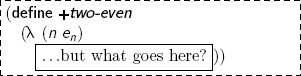

Good question.

If 5 is half of 10, then what is half of (**+** 2 10)?

<sup>16</sup>

(**+** 2 10) is the same Nat as 12, and half of 12 is 6.

If 6 is half of 12, then what is half of (**+** 2 12)?

<sup>17</sup>

(**+** 2 12) is the same Nat as 14, and half of 14 is 7.

There is a repeating pattern here.

Yes, there is a repeating pattern. This pattern can be used to fill the box.

If *a* is half of *n*, then what is half of (**+** 2 *n*)?

<sup>18</sup>

It is (add1 *a*).

But where is that *a* in the empty box?

It is (**car** *e<sub>n</sub>*) because *e<sub>n</sub>* is an (**Even** n).

This means

(**car** *e<sub>n</sub>*)

is half of *n*, and

(**cdr** *e<sub>n</sub>*)

proves this.

<sup>19</sup>

Right, because **car** and **cdr** work with expressions described by Σ.

If *p* is a

(Σ ((*x A*))

*D*),

then (**car** *p*) is an *A*, and (**cdr** *p*)’s type is found by consistently replacing each *x* in *D* with (**car** *p*).

<sup>20</sup>

That follows directly from the description in frame 10:6 on page 220.

It’s possible to go a bit further with the definition of **+*two-even*** now.

<sup>21</sup>

The body of the λ-expression has cons at the top because it must be an

(**Even** (**+** 2 *n*)).

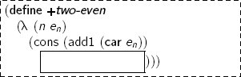

And the **car** is (add1 (**car** *e<sub>n</sub>*)) because (**car** *e<sub>n</sub>*) is half of *n*.

So far, so good.

What is (**cdr** *e<sub>n</sub>*)’s type?

<sup>22</sup>

(**cdr** *e<sub>n</sub>*) is an

(**=** Nat

*n*

(**double** (**car** *e<sub>n</sub>*))).

There is an equality proof available, and it is *almost* correct *…*

<sup>23</sup>

How can an

(**=** Nat

*n*

(**double** (**car** *e<sub>n</sub>*)))

be transformed into an

(**=** Nat

(**+** 2 *n*)

(**double** (add1 (**car** *e<sub>n</sub>*))))?

This is where the choice of **double** over **+** shows its value, just as it did when defining **double-Vec** in frame 9:59.

(**double** (add1 (**car** *e<sub>n</sub>*)))

is the same Nat as

(add1

(add1

(**double** (**car** *e<sub>n</sub>*)))).

<sup>24</sup>

And if the **cdr**’s type had been **claim**ed with **+** or **twice**, then this Nat would have been

(add1

(**+** (**car** *e<sub>n</sub>*)

(add1 (**car** *e<sub>n</sub>*)))),

and more work would have been required to bring both add1s to the top.

**Carefully Choose Definitions**

**Carefully-chosen definitions can greatly simplify later proofs.**

In frame 21’s empty box,

(**cdr** *e<sub>n</sub>*)

is an

(**=** Nat

*n*

(**double** (**car** *e<sub>n</sub>*))).

Find an expression that is an

(**=** Nat

(**+** 2 *n*)

(add1

(add1

(**double** (**car** *e<sub>n</sub>*))))).

<sup>25</sup>

The expression

(**cong** (**cdr** *e<sub>n</sub>*) (**+** 2))

has that type because

(**+** 2 *n*)

is the same Nat as

(add1

(add1 *n*)).

That is precisely what is needed to complete the proof.

<sup>26</sup>

Thanks for the hints.

(**define +*two-even***

(λ (*n e<sub>n</sub>*)

(cons (add1 (**car** *e<sub>n</sub>*))

(**cong** (**cdr** *e<sub>n</sub>*) (**+** 2)))))

Is two even?

<sup>27</sup>

Yes, it is.

Prove it, using **+*two-even***.

<sup>28</sup>

To use **+*two-even***, we need evidence that 0 is even. This evidence is in frame 9.

(**claim *two-is-even***

(*Even* 2))

(**define *two-is-even***

(**+** **two-even** 0 **zero-is-even**))

Now find the normal form.

<sup>29</sup>

The normal form takes just a few more steps.

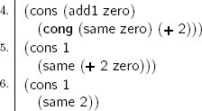

What is an odd number?

<sup>30</sup>

An odd number is not even.

Is there a more explicit way to say that?

<sup>31</sup>

Odd numbers cannot be split into two equal parts. There is always an add1 remaining.

How can that description be written as a type?

Hint: use the definition of **Even** as a guide.

<sup>32</sup>

Isn’t this an odd definition?

(**claim *Odd***

(→ Nat

*U*))

(**define *Odd***

(λ (*n*)

(Σ ((*haf* Nat))

(**=** Nat *n* (add1 (**double** haf))))))

No, but it is an **Odd** definition.

What does *haf* mean?

<sup>33</sup>

It is pretty close to *half*. It is half of the even number that is one smaller than *n*.

Here is a claim that 1 is odd.

(**claim *one-is-odd***

(**Odd** 1))

Prove it.

<sup>34</sup>

Here is the proof:

(**define *one-is-odd***

(cons 0

(same 1))).

Here, the **cdr** is

(same 1)

because

(same 1)

is an

(**=** Nat 1 (add1 (**double** 0))).

Now prove that,

“13 is odd.”

<sup>35</sup>

“Haf” of a baker’s dozen is 6.

(**claim *thirteen-is-odd***

(**Odd** 13))

(**define *thirteen-is-odd***

(cons 6

(same 13)))

If *n* is even, what can be said about (add1 *n*)?

<sup>36</sup>

Would this statement do the trick?

“If *n* is even, then (add1 *n*) is odd.”

Yes.

How can that be written as a type?

<sup>37</sup>

It uses a Π-expression and an →-expression, because the *n* means “for every *n*,” and if-then statements are translated to →-expressions.

Now translate the statement.

<sup>38</sup>

Here it is.

(**claim *add1-even→odd***

(Π ((*n* Nat))

(→ (**Even** n)

(**Odd** (add1 *n*)))))

Is that claim true?

<sup>39</sup>

Yes.

What is the evidence? Remember, truth *is the same as* having evidence, yet no evidence has been provided.

<sup>40</sup>

So the statement is false?

No.

There is neither evidence that the statement is true, nor evidence that the statement is false. For now, it is a mystery.

<sup>41</sup>

Better solve that mystery then.

To solve the mystery, think about the relationship between half of *n* and “haf” of (add1 *n*) when *n* is even.

<sup>42</sup>

They are the same Nat.

Why are they the same Nat?

<sup>43</sup>

Because the extra add1 is “used up” in the TO side of the equality in the definition of **Odd**.

Now use this important fact to prove the mystery statement and make it true.

<sup>44</sup>

*Et voilà!*

(**define *add1-even→odd***

(λ (*n e<sub>n</sub>*)

(cons (**car** *e<sub>n</sub>*)

(**cong** (**cdr** *e<sub>n</sub>*) (**+** 1)))))

Definitions should be written to be understood.

Why is this definition correct?

<sup>45</sup>

In the body of the λ-expression, there is a cons-expression. This expression is the proof of (**Odd** (add1 *n*)) because the value of (**Odd** (add1 *n*)) has Σ at the top.

What about the **car** of the proof?

<sup>46</sup>

The **car** is (**car** *e<sub>n</sub>*) because “haf” of an odd number is half of the even number that is one smaller.

And what about the **cdr** of the proof?

<sup>47</sup>

The **cdr** is built with **cong**, because

(**cdr** *e<sub>n</sub>*)

is an

(**=** Nat

*n*

(**double** (**car** *e<sub>n</sub>*))),

but the definition of (**Odd** (add1 *n*)) demands that the **cdr** be an

(**=** Nat

(add1 *n*)

(add1 (**double** (**car** *e<sub>n</sub>*)))).

The statement is now true. Take a bow.

If *n* is odd, what can be said about

(add1 *n*)?

<sup>48</sup>

Clearly,

“If *n* is odd, then (add1 *n*) is even.”

That’s quite the claim *…*

<sup>49</sup>

Indeed.

(**claim *add1-odd→even***

(Π ((*n* Nat))

(→ (**Odd** n)

(**Even** (add1 *n*)))))

Now it’s time to make that claim true.

What is “haf” of 25?

<sup>50</sup>

It is 12 because

(add1 (**double** 12))

is the same Nat as 25.

What is half of 26?

<sup>51</sup>

It is 13 because

(**double** 13)

is the same Nat as 26.

Following this template, what is the relationship between “haf” of some odd number *n* and half of (add1 *n*)?

<sup>52</sup>

If *a* is “haf” of the odd number *n*, then half of the even (add1 *n*) is (add1 *a*).

Now start the definition, using this “haf.”

<sup>53</sup>

Here it is.

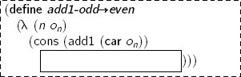

The box needs an

(**=** Nat

(add1 *n*)

(**double** (add1 (**car** *o<sub>n</sub>*)))).

Where did that type come from?

<sup>54</sup>

It came from the definition of **Even** combined with the Commandment of **cdr**.

What type does (**cdr** *o<sub>n</sub>*) have?

<sup>55</sup>

In the box,

(**cdr** *o<sub>n</sub>*)

is an

(**=** Nat

*n*

(add1 (**double** (**car *o<sub>n</sub>***)))).

How can (**cdr** *o<sub>n</sub>*) be used to construct evidence that

(**=** Nat

(add1 *n*)

(**double** (add1 (**car** *o<sub>n</sub>*))))?

<sup>56</sup>

**cong** does the trick, because

(**double** (add1 (**car** *o<sub>n</sub>*)))

is the same Nat as

(add1

(add1

(**double** (**car** *o<sub>n</sub>*)))).

(**define *add1-odd→even***

(λ (*n o<sub>n</sub>*)

(cons (add1 (**car** *o<sub>n</sub>*))

(**cong** (**cdr** *o<sub>n</sub>*) (**+** 1)))))

That definition deserves a solid box.

<sup>57</sup>

Whew! It’s time for another *fika*.

**Go eat a haf a baker’s dozen muffins**

**and get ready to divide by two.**

**Behold! Ackermann!**

(**claim *repeat***

(→ (→ Nat

Nat)

Nat

Nat))

(**define *repeat***

(λ (*f n*)

(**iter-Nat** *n*

(*f* 1)

(λ (*iter<sub>f,n-1</sub>*)

(*f iter<sub>f,n-1</sub>*)))))

(**claim *ackermann***

(→ Nat Nat

Nat))

(**define *ackermann***

(λ (*n*)

(**iter-Nat** *n*

(**+** 1)

(λ (*ackermann<sub>n-1</sub>*)

(**repeat** ackermann<sub>n-1</sub>)))))

[figure not shown]

| Is every natural number either even or odd? | <sup>1</sup> | They might be. But where’s the evidence? |
| --- | --- | --- |
| Writing “Every natural number is either even or odd.” as a type requires a new type constructor: Either, which is used to write “or” as a type. | <sup>2</sup> | That seems reasonable. When does Either construct a type? |
| (Either *L R*) is a type if *L* is a type and *R* is a type. | <sup>3</sup> | What are the values of (Either *L R*)? |

**The Law of** Either

**(**Either *L R***) is a type if** *L* **is a type and** *R* **is a type.**

| There are two constructors. If *lt* is an *L*, then (left *lt*) is an (Either *L R*). If *rt* is an *R*, then (right *rt*) is an (Either *L R*). When are two (Either *L R*) values the same? | <sup>4</sup> | Here’s a guess based on earlier types. (left *lt*<sub>1</sub>) and (left *lt*<sub>2</sub>) are the same (Either *L R*) if *lt*<sub>1</sub> and *lt*<sub>2</sub> are the same *L*. |
| --- | --- | --- |
| So far, so good. Anything to add? | <sup>5</sup> | Yes, one more thing. (right *rt*<sub>1</sub>) and (right *rt*<sub>2</sub>) are the same (Either *L R*) if *rt*<sub>1</sub> and *rt*<sub>2</sub> are the same *R*. |

**The Law of** left

**(**left *lt***) is an (**Either *L R***) if** *lt* **is an** *L***.**

**The Law of** right

**(**right *rt***) is an (**Either *L R***) if** *rt* **is an** *R***.**

| Any other possibilities? | <sup>6</sup> | Probably not. |
| --- | --- | --- |
| That is indeed all of the possibilities. The eliminator for Either is called **ind-Either**. | <sup>7</sup> | That’s not a surprise. |
| **ind-Either** has two bases, but no step. Why is that? | <sup>8</sup> | It is because there are two ways to construct an (Either *L R*), but neither left nor right has an (Either *L R*) as an argument. |
| So can **ind-Either** introduce recursion? | <sup>9</sup> | No, because neither left nor right, Either’s two constructors, are recursive. |
| In an **ind-Either**-expression (**ind-Either** *target* *mot* *base-left* *base-right*), *target* is an (Either *L R*). | <sup>10</sup> | Does *mot* explain why *target* is being eliminated? |
| As usual, it does. *mot’*s type is (→ (Either *L R*) *U*). *base-left* explains *how* the motive is fulfilled for every left. That is, *base-left’*s type is (Π ((*x L*)) (*mot* (left *x*))). | <sup>11</sup> | Is *base-right’*s type built the same way? |
| Yes, it is. *base-right* explains *how* the motive is fulfilled for every right. What is *base-right’*s type? | <sup>12</sup> | *base-right’*s type is (Π ((*y R*)) (*mot* (right *y*))) because “every” becomes a Π-expression when written as a type. |
| What is the value of (**ind-Either** (left *x*) *mot* *base-left* *base-right*)? | <sup>13</sup> | It is the value of (*base-left x*), which is the only available expression with the correct type. |
| What is the value of (**ind-Either** (right *y*) *mot* *base-left* *base-right*)? | <sup>14</sup> | It is the value of (*base-right y*), for the same reason. |

**The Law of ind-Either**

**If** *target* **is an (**Either *L R***),** *mot* **is an**

**(**→ **(**Either *L R***)**

*U***)**,

*base-left* **is a**

**(Π ((***x L***))**

**(***mot* **(**left *x***)))**,

**and** *base-right* **is a**

**(Π ((***y R***))**

**(***mot* **(**right *y***)))**

**then**

**(ind-Either** *target*

*mot*

*base-left*

*base-right***)**

**is a (***mot target***).**

**The First Commandment of ind-Either**

**(ind-Either (**left *x***)**

*mot*

*base-left*

*base-right***)**

**is the same (***mot* **(**left *x***)) as (***base-left x***).**

**The Second Commandment of ind-Either**

**(ind-Either (**right *y***)**

*mot*

*base-left*

*base-right***)**

**is the same (***mot* **(**right *y***)) as (***base-right y***).**

Now we know how to write,

“Every natural number is even or odd.”

as a type.

(**claim *even-or-odd***

(Π ((*n* Nat))

(Either (**Even** n) (**Odd** n))))

<sup>15</sup>

This is a claim about all Nats. Does the proof use **ind-Nat**?

Yes, it does.

**mot-even-or-odd** describes the purpose of the elimination. Try to define it without finding the base first.

(**claim *mot-even-or-odd***

(→ Nat

*U*))

<sup>16</sup>

Abstracting over *n* in frame 15 does it.

(**define *mot-even-or-odd***

(λ (*k*)

(Either (**Even** k) (**Odd** k))))

Good choice.

What is the base?

<sup>17</sup>

The base is an

(Either (**Even** zero) (**Odd** zero))

and zero happens to be even.

Sound familiar?

<sup>18</sup>

Yes, it does.

The base is

(left **zero-is-even**).

It is.

What is the type of the step?

<sup>19</sup>

The type of the step is found using the motive.

(**claim *step-even-or-odd***

(Π ((*n-1* Nat))

(→ (**mot-even-or-odd** n-1)

(**mot-even-or-odd** (add1 *n-1*)))))

Now define **step-even-or-odd**.

<sup>20</sup>

Here’s a start *…*

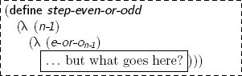

What is *e-or-o<sub>n-1</sub>*’s type?

<sup>21</sup>

The type comes from the step’s claim.

What is the eliminator for Either?

<sup>22</sup>

**ind-Either**, of course.

So eliminate it.

<sup>23</sup>

Here’s a version with empty boxes in it, at least.

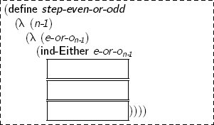

Good start.

What is the motive?

<sup>24</sup>

According to **step-even-or-odd**’s claim, the elimination produces a

(**mot-even-or-odd** (add1 *n-1*)).

Instead of defining a separate motive, try writing a λ-expression this time. The argument to the motive is the target, but this elimination is not producing a type that depends on the target. So the motive’s argument can be dim.

<sup>25</sup>

That’s a lot shorter than defining it separately.

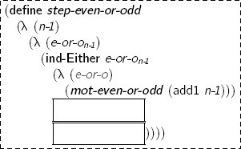

Yes, it is shorter. But shorter is not always easier to read. Compare the two styles and decide which is easier to understand in each case.

When *n-1* is even, what is the evidence that (add1 *n-1*) is odd?

<sup>26</sup>

The evidence can be constructed with **add1-even→odd**.

The first empty box in frame 25 is an

(→ (**Even** n-1)

(Either

(**Even** (add1 *n-1*))

(**Odd** (add1 *n-1*)))).

<sup>27</sup>

The Law of **ind-Either** states that the base for left is a

(Π ((*x L*))

(*mot* (left *x*))),

so why doesn’t the empty box’s type have Π at the top?

The type has Π at the top. Because → is another way of writing Π when its argument name is not used, → is sufficient, as seen in frame 6:40.

<sup>28</sup>

Because (add1 *n-1*) is odd, the expression uses right:

(λ (*e<sub>n-1</sub>*)

(right

(**add1-even→odd** n-1 e<sub>n-1</sub>))).

That’s right.

What about the last box?

<sup>29</sup>

In that box, *n-1* is odd. Thus, (add1 *n-1*) is even and the expression uses left:

(λ (*o<sub>n-1</sub>*)

(left

(**add1-odd→even** n-1 o<sub>n-1</sub>))).

Now assemble the definition of **step-even-or-odd**.

<sup>30</sup>

The boxes are filled in.

(**define *step-even-or-odd***

(λ (*n-1*)

(λ (*e-or-o<sub>n-1</sub>*)

(**ind-Either** *e-or-o<sub>n-1</sub>*

(λ (*e-or-o<sub>n-1</sub>*)

(**mot-even-or-odd**

(add1 *n-1*)))

(λ (*e<sub>n-1</sub>*)

(right

(**add1-even→odd**

*n-1 e<sub>n-1</sub>*)))

(λ (*o<sub>n-1</sub>*)

(left

(**add1-odd→even**

*n-1 o<sub>n-1</sub>*)))))))

Now, define **even-or-odd**.

<sup>31</sup>

The pieces are ready.

(**define *even-or-odd***

(λ (*n*)

(**ind-Nat** *n*

**mot-even-or-odd**

(left **zero-is-even**)

**step-even-or-odd**)))

**even-or-odd** is a proof that

“Every natural number is even or odd.”

But it is more than just a proof—it is a λ-expression that produces a value when it gets an argument.

<sup>32</sup>

It always produces a value because all functions are total.

Is this value interesting?

Let’s find out.

What is the value of (**even-or-odd** 2)?

<sup>33</sup>

That’s an interesting question.

Get ready for a long “same-as” chart. Here’s the beginning.

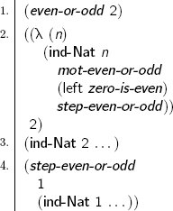

In this chart, *…*, an ellipsis, stands for the arguments to **ind-Nat** or **ind-Either** that don’t change at all.

<sup>34</sup>

Here’s the next one.

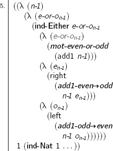

At each step, look for the parts of expressions that change and those that don’t.

Try to identify motives, bases, and steps that appear multiple times.

<sup>35</sup>

What about targets?

Targets are rarely repeated, but worth watching.

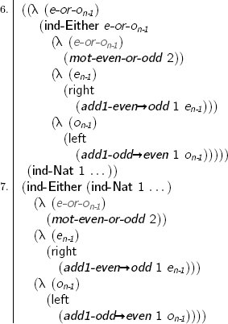

<sup>36</sup>

Ah, because as soon as a target’s value is found, a base or step is chosen.

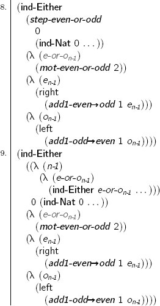

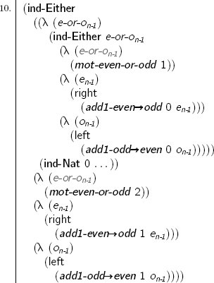

<sup>37</sup>

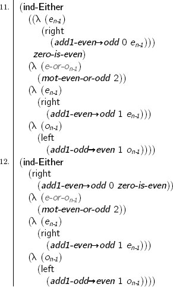

<sup>38</sup>

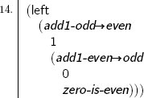

The last expression in the chart is a value.

Whew!

Indeed,

(left

(**add1-odd→even**

1

(**add1-even→odd**

0

**zero-is-even**)))

is a value.

What can we learn from this value?

<sup>39</sup>

From this value, it is clear that 2 is even, because the value has left at the top.

In this case, there is still more to be learned.

Find the normal form of

(left

(**add1-odd→even**

1

(**add1-even→odd**

0

**zero-is-even**))).

<sup>40</sup>

The first step in finding the normal form is to replace **add1-odd→even** with its definition.

That’s right.

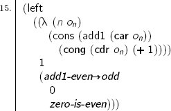

What is next?

<sup>41</sup>

The next step is to replace *n* with 1 and **add1-even→odd** with its definition.

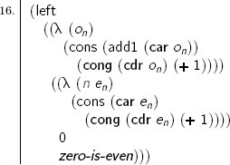

The next step is to drop in the definition of **zero-is-even**.

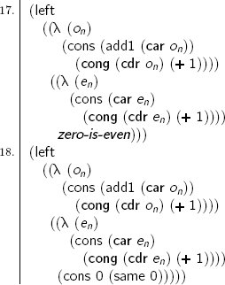

What’s next?

<sup>42</sup>

Next, find the **car** and **cdr** of *e<sub>n</sub>*.

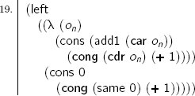

It looks like the next step is to find the value of

(**cong** (same 0) (**+** 1)),

and by the Commandment of **cong**, that value is

(same 1).

Here’s the next step.

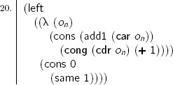

What remains?

<sup>43</sup>

There is one more **cong**-expression that can be made more direct.

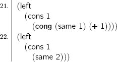

What can be learned from this normal form?

<sup>44</sup>

From the value, we see that 2 is even. The normal form also has the *proof* that 2 is even tucked under left.

Each step in the “same as” chart is the same as the previous step, so the value also contains the proof.

<sup>45</sup>

Normal forms, however, are often easier to understand, and this one is no exception.

What can be learned from such a proof?

<sup>46</sup>

Not only that 2 is even, but also that 1 is half of 2.

Definitions like **even-or-odd** play two roles. In the first role, **even-or-odd** is a *proof* that every Nat is either even or odd.

<sup>47</sup>

What is the other role?

In the second role, **even-or-odd** is a *function* that can determine *whether* a Nat is even or odd. To do so, it finds either half or “haf” of the Nat.

<sup>48</sup>

**even-or-odd** is interesting *both* as evidence for a statement *and* for the results that it finds.

Exactly. Now, it’s time to go for a nice relaxing walk in the woods.

<sup>49</sup>

Sounds good.

**Every number is even or odd,**

**and some are smaller than others.**

**Get ready.**

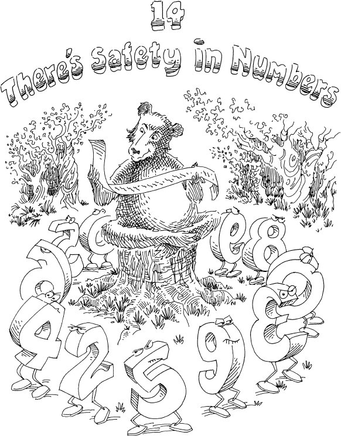

Please select a dish from this menu:

- ratatouille,
- kartoffelmad,
- hero sandwich, or
- prinsesstårta.

<sup>1</sup>

The fourteenth, please.

There are only four dishes on the menu, so you don’t get anything.

<sup>2</sup>

That’s unfortunate.

In order to pick a specific entry from a list, we must know what to do when there are not enough entries.

<sup>3</sup>

One might say that there may be an entry, but there also may not be.

To represent the case when there is no entry, we need a new type, called Trivial.†

_______________

†Sometimes called the *unit* type.

<sup>4</sup>

What is Trivial?

Trivial is a type, and sole is a Trivial.

Every Trivial expression is the same Trivial as sole.

<sup>5</sup>

What about neutral Trivial expressions?

Yes, neutral Trivial expressions are the same as sole. And that’s all there is to say about Trivial.

<sup>6</sup>

This type is appropriately named.

**The Law of** Trivial

Trivial **is a type.**

**The Law of** sole

sole **is a** Trivial.

**The Commandment of** sole

**If** *e* **is a** Trivial**, then** *e* **is the same as** sole.

That an entry may or may not be in a list can be represented using **Maybe**.

(**claim *Maybe***

(→ *U*

*U*))

<sup>7</sup>

How can **Maybe** represent presence or absence?

There is either an *X* or a Trivial.

(**define *Maybe***

(λ (*X*)

(Either *X* Trivial)))

<sup>8</sup>

Okay.

Absence is indicated using (right sole).

(**claim *nothing***

(Π ((*E U*))

(**Maybe** E)))

(**define *nothing***

(λ (*E*)

(right sole)))

<sup>9</sup>

Presumably, presence uses left.

Indeed it does. Here is the claim.

(**claim *just***

(Π ((*E U*))

(→ *E*

(**Maybe** E))))

<sup>10</sup>

In order to use left, an *E* is necessary.

(**define *just***

(λ (*E e*)

(left *e*)))

Using **Maybe**, it is possible to write a total version of **head** for List.

(**claim *maybe-head***

(Π ((*E U*))

(→ (List *E*)

(**Maybe** E))))

<sup>11</sup>

Following the type, the definition begins with λ.

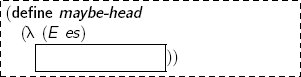

What should we expect from (**maybe-head** Atom nil)?

<sup>12</sup>

It should be (**nothing** Atom) because the empty list has no head.

What should we expect from

(**maybe-head** Atom

(:: **'**ratatouille

(:: **'**kartoffelmad

(:: (*sandwich* 'hero)

(:: **'**prinsesstårta nil)))))?

<sup>13</sup>

It should be (**just** Atom **'**ratatouille).

This is enough information to find the base and step for **rec-List** in the empty box.

<sup>14</sup>

Plenty of information.

(**define *maybe-head***

(λ (*E es*)

(**rec-List** *es*

(**nothing** E)

(λ (*hd tl head<sub>tl</sub>*)

(**just** E hd)))))

What type should **maybe-tail** have?

<sup>15</sup>

It is similar to **maybe-head**, except that it (maybe) finds a list.

(**claim *maybe-tail***

(Π ((*E U*))

(→ (List *E*)

(**Maybe** (List *E*)))))

The definition of **maybe-tail** is also very similar to the definition of **maybe-head**. Only the type in the base and the step’s type and value need to change.

<sup>16</sup>

(**define *maybe-tail***

(λ (*E es*)

(**rec-List** *es*

(**nothing** (List *E*))

(λ (*hd tl tail<sub>tl</sub>*)

(**just** (List *E*) *tl*)))))

**maybe-head** and **maybe-tail** can be used to define **list-ref**, which either finds or does not find a specific entry in a list.

<sup>17</sup>

What is **list-ref** ’s type?

**list-ref** accepts an entry type, a Nat, and a list. It may or may not find an entry.

(**claim *list-ref***

(Π ((*E U*))

(→ Nat (List *E*)

(**Maybe** E))))

What should we expect from

(**list-ref** Atom 0 nil)?

<sup>18</sup>

We should expect nothing, because nil has no entries.

Or, rather, we should expect

(**nothing** Atom).

What about

(**list-ref** Atom

zero

(:: **'**ratatouille

(:: **'**kartoffelmad

(:: (*sandwich* 'hero)

(:: **'**prinsesstårta nil)))))?

<sup>19</sup>

That’s just **'**ratatouille, or rather,

(**just** Atom **'**ratatouille).

In other words, when the Nat is zero, **list-ref** acts just like **maybe-head**.

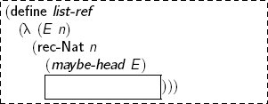

<sup>20</sup>

That’s why **maybe-head** is the base.

What is the step?

The base is an

(→ (List *E*)

(**Maybe** E)).

What is the step’s type?

<sup>21</sup>

It should work for any entry type *E*.

(**claim *step-list-ref***

(Π ((*E U*))

(→ Nat

(→ (List *E*)

(**Maybe** E))

(→ (List *E*)

(**Maybe** E)))))

The step takes as its argument a **list-ref** for some smaller Nat, which is *almost* a **list-ref** for *this* Nat.

How can a **list-ref** for *n-1* be transformed into a **list-ref** for *n*?

<sup>22</sup>

The **list-ref** for *n-1* can be applied to the tail of the list.

Complete this definition.

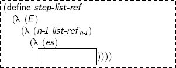

<sup>23</sup>

*list-ref<sub>n-1</sub>* can be used when *maybe-tail* of *es* finds a (List *E*). When *maybe-tail* finds *nothing*, the step finds *nothing*.

(**define *step-list-ref***

(λ (*E*)

(λ (*n-1 list-ref <sub>n-1</sub>*)

(λ (*es*)

(**ind-Either** (**maybe-tail** E es)

(λ (*maybe<sub>tl</sub>*)

(**Maybe** E))

(λ (*tl*)

(*list-ref <sub>n-1</sub> tl*))

(λ (*empty*)

(**nothing** E)))))))

Now define **list-ref**.

<sup>24</sup>

Here it is.

(**define *list-ref***

(λ (*E n*)

(**rec-Nat** *n*

(**maybe-head** E)

(**step-list-ref** E))))

Take a short break, and maybe eat  
some delicious ratatouille.

Please select a dish from *this* menu:

1. ratatouille,
2. kartoffelmad,
3. hero sandwich, or
4. prinsesstårta.

<sup>25</sup>

The fourteenth, please.

What does “fourteenth” mean?

<sup>26</sup>

Ah, there are *precisely* four entries.

What is the difference between a Vec and a List?

<sup>27</sup>

In a Vec, the type states how many entries there are. This second menu must be a Vec.

That’s right.

(**claim *menu***

(Vec Atom 4))

(**define *menu***

(vec:: **'**ratatouille

(vec:: **'**kartoffelmad

(vec:: (*sandwich* 'hero)

(vec:: **'**prinsesstårta vecnil)))))

<sup>28</sup>

That’s one **'**delicious hero sandwich.

To define **vec-ref**, a new type is needed: one that represents only numbers smaller than the length of the Vec.

This type is called (**Fin** *ℓ*), where *ℓ* is the length.

<sup>29</sup>

Why is it called **Fin**?

**Fin** is a very finite way of writing “finite.”

<sup>30</sup>

Another abbreviation.

How many natural numbers are smaller than zero?

<sup>31</sup>

There are no such numbers.

This requires a new type constructor, named Absurd.†

_______________

†Absurd is sometimes referred to as the *empty type*.

<sup>32</sup>

That’s an absurd name.

When is Absurd a type?

Absurd is always a type, just like Atom, Nat, *U*, and Trivial are always types.

<sup>33</sup>

That’s easy enough.

What are the values of Absurd?

**The Law of** Absurd

Absurd **is a type.**

[output not shown]

**The Commandment of Absurdities**

**Every expression of type** Absurd **is neutral, and all of them are the same.**

[output not shown]

**The Law of ind-Absurd**

**The expression**

**(ind-Absurd** *target*

*mot***)**

**is a** *mot* **if** *target* **is an** Absurd **and** *mot* **is a** *U***.**

It is used to express that some expressions can never be evaluated, or in other words, that the expression is permanently neutral.

<sup>43</sup>

And neutral expressions cannot yet be evaluated because the values of their variables are not yet known.

For each Nat *n*, (**Fin** n) should be a type with *n* values.

(**claim *Fin***

(→ Nat

*U*))

What should the value of (**Fin** zero) be?

<sup>44</sup>

(**Fin** zero) should have zero values, so Absurd is appropriate.

Here is the beginning of **Fin**’s definition.

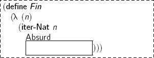

What goes in the empty box?

<sup>45</sup>

The step for **Fin**, which goes in the empty box, should transform a type with *n-1* values into a type with *n* values.

How many values have the type

(**Maybe** Absurd)?

<sup>46</sup>

There is just one,

(**nothing** Absurd),

which has the normal form

(right sole).

What about Either’s constructor left?

<sup>47</sup>

That would require an Absurd value, and there are no Absurd values.

How many values have the type

(**Maybe**

(**Maybe** Absurd))?

<sup>48</sup>

There are two possibilities:

(**nothing** (**Maybe** Absurd)),

and

(**just** (**Maybe** Absurd)

(**nothing** Absurd)).

Based on these examples, if a type *X* has *n* values, how many values does

(**Maybe** X)

have?

<sup>49</sup>

It has (add1 *n*) values because **Maybe** adds one value, which is (**nothing** X).

This means that **Maybe** is a suitable step for **Fin**.

Indeed it is.

<sup>50</sup>

Here is the definition.

(**define *Fin***

(λ (*n*)

(**iter-Nat** *n*

Absurd

**Maybe**)))

What is the normal form of (**Fin** 1)?

<sup>51</sup>

This type has 1 value.

What is the normal form of (**Fin** 2)?

<sup>52</sup>

It is

(**Maybe**

(**Maybe** Absurd)),

better known as

(Either (Either Absurd

Trivial)

Trivial),

which has 2 values.

To use **Fin** to pick out entries in a Vec, it is necessary to determine which **Fin** points at which entry.

The first entry in a Vec is found using (**fzero** n) when the Vec has (add1 *n*) entries.

(**claim *fzero***

(Π ((*n* Nat))

(**Fin** (add1 *n*))))

<sup>53</sup>

This is because there are no entries when the length is zero.

Take another look at the definition of **Fin** in frame 50. What is another way of writing **fzero**’s type?

<sup>54</sup>

**iter-Nat** applies the step when the target has add1 at the top, so **fzero**’s type and

(Π ((*n* Nat))

(**Maybe** (**Fin** n)))

are the same type.

In that type, what are (**Fin** n)’s values?

<sup>55</sup>

That depends on *n*’s values.

This means that a good choice for **fzero**’s definition is *…*

<sup>56</sup>

… (**nothing** (**Fin** n)), even though it is something rather than nothing.

Good choice. Now define **fzero**.

<sup>57</sup>

Here it is.

(**define *fzero***

(λ (*n*)

(**nothing** (**Fin** n))))

Just as (**fzero** n) points at the head of a (Vec *X* (add1 *n*)), **fadd1** points somewhere in its tail.

(**claim *fadd1***

(Π ((*n* Nat))

(→ (**Fin** n)

(**Fin** (add1 *n*)))))

<sup>58</sup>

Why do the two **Fin**s have different arguments?

Take a look at frame 48. There are two values for (**Fin** 2). The first is

(**nothing** (**Maybe** Absurd)),

also known as (**fzero** 1).

What is the other?

<sup>59</sup>

The other is

(**just** (**Maybe** Absurd)

(**nothing** Absurd)).

For each layer of **Maybe** in the type, there is a choice between either stopping with **fzero** (also known as **nothing**) and continuing with **just** a value from the smaller type.

Now define **fadd1**.

<sup>60</sup>

It adds the extra **just**.

(**define *fadd1***

(λ (*n*)

(λ (*i-1*)

(**just** (**Fin** n) *i-1*))))

Now it’s time to define **vec-ref**, so that there’s always something to eat from the menu.

(**claim *vec-ref***

(Π ((*E U*)

(*ℓ* Nat))

(→ (**Fin** ℓ) (Vec *E* *ℓ*)

*E*)))

<sup>61</sup>

Here, there is no **Maybe**.

There are three possibilities:

1. the length *ℓ* is zero,
2. the length *ℓ* has add1 at the top and the **Fin** is **fzero**, or
3. the length *ℓ* has add1 at the top and the **Fin** is **fadd1**.

<sup>62</sup>

It depends first and foremost on *ℓ*. The motive is built by abstracting the rest of the type over *ℓ*.

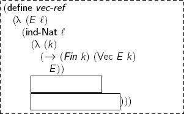

Good start. What is the base’s type?

<sup>63</sup>

Apply the motive to zero.

(**claim *base-vec-ref***

(Π ((*E U*))

(→ (**Fin** zero) (Vec *E* zero)

*E*)))

The only constructor for (Vec *E* zero) is vecnil, but vecnil does not contain any *E*s.

What is the value of (**Fin** zero)?

<sup>64</sup>

The value of (**Fin** zero) is Absurd.

Because there are no Absurd values, the base can never be applied to its second argument’s value.

Use **ind-Absurd** to take advantage of this fact.

<sup>65</sup>

Okay.

(**define *base-vec-ref***

(λ (*E*)

(λ (*no-value-ever es*)

(**ind-Absurd** *no-value-ever*

*E*))))

Now it is time to define the step.

What is the step’s type?

<sup>66</sup>

Once again, it is found by the Law of **ind-Nat**.

(**claim *step-vec-ref***

(Π ((*E U*)

(*ℓ**-1* Nat))

(→ (→ (**Fin** ℓ-1)

(Vec *E* *ℓ-1*)

*E*)

(→ (**Fin** (add1 *ℓ**-1*))

(Vec *E* (add1 *ℓ**-1*))

*E*))))

There are now two possibilities remaining:

1. the **Fin** is **fzero**, or
2. the **Fin** is **fadd1**.

What is the value of (**Fin** (add1 *ℓ**-1*))?

<sup>67</sup>

The value has Either at the top.

What can be used to check which Either it is?

<sup>68</sup>

The only eliminator for Either is **ind-Either**.

If the **Fin** is **fzero**, then it has right at the top, and if it is **fadd1**, then it has left at the top.

If the **Fin** has left at the top, then there should be recursion to check the Vec’s tail. If it has right at the top, then find the Vec’s **head**.

<sup>69</sup>

**ind-Either** is used to distinguish between Either’s constructors.

Indeed it is. Define the step.

<sup>70</sup>

Here goes.

(**define *step-vec-ref***

(λ (*E ℓ-1*)

(λ (*vec-ref <sub>ℓ-1</sub>*)

(λ (*i es*)

(**ind-Either** *i*

(λ (*i*)

*E*)

(λ (*i-1*)

(*vec-ref <sub>ℓ-1</sub>*

*i-1* (**tail** *es*)))

(λ (*triv*)

(**head** *es*)))))))

Now define **vec-ref**.

<sup>71</sup>

The boxes are all filled.

(**define *vec-ref***

(λ (*E ℓ*)

(**ind-Nat** *ℓ*

(λ (*k*)

(→ (**Fin** k) (Vec *E k*)

*E*))

(**base-vec-ref** E)

(**step-vec-ref** E))))

Now that it’s clear how to find entries in **menu**, which one do you want?

<sup>72</sup>

The second one.

The second one?

<sup>73</sup>

Pardon me.

The

(**fadd1** 3

(**fzero** 2))nd one,

please.

Let’s find it. Here’s the first few steps.

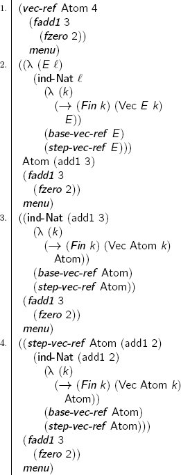

<sup>74</sup>

The motive, base, and step in the **ind-Nat**-expression do not change, so they are replaced with an ellipsis, just like in frame 13:34.

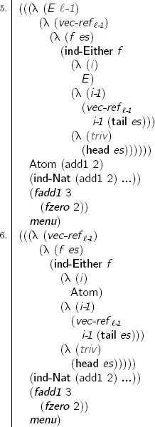

That’s a good start.

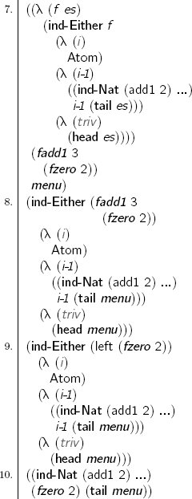

<sup>75</sup>

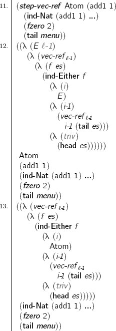

Almost there!

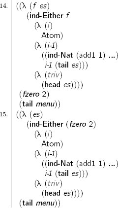

<sup>76</sup>

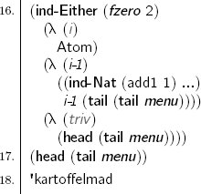

Finally, my **'**kartoffelmad is here.

**Enjoy your smørrebrød**

**things are about to get subtle.**

**Turner’s Teaser**

Define a function that determines whether another function that accepts any number of Eithers always returns left. Some say that this can be difficult with types.† Perhaps they are right; perhaps not.

(**claim *Two***

*U*)

(**define *Two***

(Either Trivial Trivial))

(**claim *Two-Fun***

(→ Nat

*U*))

(**define *Two-Fun***

(λ (*n*)

(**iter-Nat** *n*

**Two**

(λ (*type*)

(→ **Two**

*type*)))))

(**claim *both-left***

(→ **Two Two**

*Two*))

(**define *both-left***

(λ (*a b*)

(**ind-Either** *a*

(λ (*c*)

**Two**)

(λ (*left-sole*)

*b*)

(λ (*right-sole*)

(right sole)))))

(**claim *step-taut***

(Π ((*n-1* Nat))

(→ (→ (**Two-Fun** n-1)

**Two**)

(→ (**Two-Fun** (add1 *n-1*))

**Two**))))

(**define *step-taut***

(λ (*n-1 taut<sub>n-1</sub>*)

(λ (*f* )

(**both-left**

(*taut<sub>n-1</sub>*

(*f* (left sole)))

(*taut<sub>n-1</sub>*

(*f* (right sole)))))))

(**claim *taut***

(Π ((*n* Nat))

(→ (**Two-Fun** n)

**Two**)))

(**define *taut***

(λ (*n*)

(**ind-Nat** *n*

(λ (*k*)

(→ (**Two-Fun** k)

**Two**))

(λ (*x*)

*x*)

**step-taut**)))

_______________

†Thanks, David A. Turner (1946–).

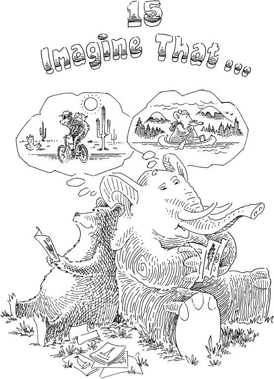

We have proved that many different expressions are equal.

<sup>1</sup>

That’s right.

Not every pair of expressions are equal, however. Clearly,

“39 is not equal to 117.”

<sup>2</sup>

Can that statement also be written as a type?

A statement is true when we have evidence that it is true. False statements have no evidence at all.

<sup>3</sup>

This sounds like Absurd.

It does.

The eliminator **ind-Absurd** corresponds to a principle of thought.

<sup>4</sup>

What principle is that?

If a false statement were true, then we might as well say anything at all.

<sup>5</sup>

Sounds reasonable enough.

That principle† is induction for Absurd.

Here is the type that captures the meaning of the statement from frame 2.

(→ (**=** Nat 39 117)

Absurd)

_______________

†Also known as *the Principle of Explosion* or *ex falso quodlibet*, which means “from false, anything.”

<sup>6</sup>

Why does

(→ *X*

Absurd)

capture the meaning of “not *X*?”

It says,

“If there were a proof that 39 equals 117, then there would be a proof of Absurd.”

<sup>7</sup>

Providing evidence that 39 equals 117 as an argument to the function, whose type is in the preceding frame, would result in a proof of Absurd. And we know that no such proof exists.

There is no proof of Absurd, so there can’t be a proof of (**=** Nat 39 117).

<sup>8</sup>

But if there are no Absurd values, then how can a “not” statement have a proof?

What could be in the body of the λ-expression?

The key is to carefully avoid having to write the body of the λ-expression.

<sup>9</sup>

How can that be achieved?

With attention to detail and an open mind.

First, we define what the consequences are of the fact that two Nats are equal.

<sup>10</sup>

What are the consequences?

It depends on which Nats they are.

(**claim *=consequence***

(→ Nat Nat

*U*))

<sup>11</sup>

Okay. What is the definition of **=consequence**?

If zero equals zero, nothing interesting is learned. This can be represented using Trivial.

<sup>12</sup>

What does Trivial mean as a statement?

To understand Trivial as a *statement*, consider how to prove it.

<sup>13</sup>

There is sole.

That’s the proof.

<sup>14</sup>

Rather trivial.

Is there an eliminator for Trivial?

There could be, but it would be pointless.

There is only one Trivial value, so nothing is to be learned from eliminating it.

<sup>15</sup>

So Trivial is a boring statement that can always be proved.

Just like Π and Σ, normal expressions with type Trivial are always values.

<sup>16</sup>

This is because every expression with type Trivial is the same as sole.

The fact that Trivial is not an interesting statement makes it a perfect type to represent that nothing is learned from

(**=** Nat zero zero).

<sup>17</sup>

What else can be learned if two Nats are equal?

If

(**=** Nat (add1 *n-1*) zero)

or

(**=** Nat zero (add1 *j-1*))

is true, then anything at all can be true. So the consequence is Absurd.

<sup>18</sup>

That makes sense.

Finally, if

(**=** Nat (add1 *n-1*) (add1 *j-1*))

is true, what is the consequence?

<sup>19</sup>

It must be that *n-1* and *j-1* are equal Nats.

<sup>20</sup>

The function is not recursive, so **which-Nat** is enough.

Here is **=consequence**’s definition.

Check that each part of the table matches.

(**define *=consequence***

(λ (*n j*)

(**which-Nat** *n*

(**which-Nat** *j*

Trivial

(λ (*j-1*)

Absurd))

(λ (*n-1*)

(**which-Nat** *j*

Absurd

(λ (*j-1*)

(**=** Nat *n-1 j-1*)))))))

<sup>21</sup>

Each does.

If **=consequence** tells us it is true about two equal Nats, then it should certainly be true when the Nats are the same.

How can this goal be written as a type?

<sup>22</sup>

*n* is clearly the same Nat as *n*.

(**claim *=consequence-same***

(Π ((*n* Nat))

(**=consequence** n n)))

That’s right.

<sup>23</sup>

Here’s the start of a proof.

The motive is built by abstracting the **ind-Nat**-expression’s type over *n*.

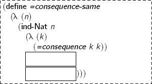

What is the base’s type?

<sup>24</sup>

As usual, the base’s type is the motive applied to zero, which is

Trivial.

So the base is

sole.

What about the step?

<sup>25</sup>

The step’s type is

(Π ((*n-1* Nat))

(→ (**=consequence** n-1 n-1)

(**=consequence**

(add1 *n-1*)

(add1 *n-1*)))),

which is also found by applying the motive.

The step has λ at the top. What type is expected in the empty box?

<sup>26</sup>

The value of

(**=consequence** (add1 *n-1*) (add1 *n-1*))

is

(**=** Nat *n-1 n-1*).

*n-1* and *n-1* are the same Nat, so (same *n-1*) fits in this box.

Now fill in the boxes and define **=consequence-same**.

<sup>27</sup>

Like **zerop**, the step’s second argument is dim because the function is not recursive.

(**define *=consequence-same***

(λ (*n*)

(**ind-Nat** *n*

(λ (*k*)

(**=consequence** k k))

sole

(λ (*n-1 =consequence<sub>n-1</sub>*)

(same *n-1*)))))

Could **=consequence-same** have been defined with **which-Nat**?

<sup>28</sup>

No. Because the type of the **ind-Nat**-expression depends on the target, **ind-Nat** is needed.

Now comes the tricky part.

The proof of **=consequence** for Nats that are the same can be used to prove **=consequence** for any two *equal* Nats.

<sup>29</sup>

If two Nats are equal, aren’t they the same?

Not necessarily. Using types, it is possible to *assume* things that may or may not be true, and then see what can be concluded from these assumptions.

How can the type

(→ (**=** Nat 0 6)

(**=** Atom **'**powdered **'**glazed))

be read as a statement?

<sup>30</sup>

That type can be read,

“If zero equals six, then powdered donuts are glazed donuts.”

Because there is no evidence that

“Zero equals six,”

there are no suitable arguments for this function.

This is fortunate for those who have discriminating taste in desserts.

<sup>31</sup>

Donuts can be part of a mid-afternoon *fika* as well as dessert.

**Imagine That …**

**Using types, it is possible to *assume* things that may or may not be true, and then see what can be concluded from these assumptions.**

[output not shown]

**Sameness versus Equality**

**Either two expressions are the same, or they are not. It is impossible to prove that they are the same because sameness is a judgment, not a type, and a proof is an expression with a specific type.**

Even the Absurd consequences.

It is not possible to prove Absurd, but it is possible to exclude those two Absurd cases using the equality assumption.

<sup>35</sup>

So the statement to be proved is

“If *n* and *j* are equal Nats, then the consequences from frame 20 follow.”

Here is that statement as a type that explains how a proof that *n* and *j* are equal can be used.

(**claim *use-Nat=***

(Π ((*n* Nat)

(*j* Nat))

(→ (**=** Nat *n j*)

(**=consequence** n j))))

<sup>36</sup>

The proof definitely has λs at the top.

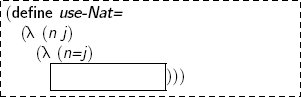

Here comes the trick.

**replace** can make *n* the same as *j*, which allows **=consequence-same** to prove **use-Nat=**.

<sup>37</sup>

But what if they are not the same?

Then there is no need to worry.

If there is no evidence that *n* equals *j*, then there are no suitable arguments.

<sup>38</sup>

Here is the definition with **replace** in the box.

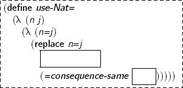

The target is *n=j*.

Should *n* or *j* be the argument to **=consequence-same**?

What is the FROM and what is the TO in *n=j*’s type?

<sup>39</sup>

The FROM is *n* and the TO is *j*. This means that the base’s type is the motive applied to *n*.

What about the entire **replace**-expression’s type?

<sup>40</sup>

It is the motive applied to *j*.

The base must be

(**=consequence-same** n)

because the FROM is *n*.

What should the motive be?

<sup>41</sup>

The whole **replace**-expression is an

(**=consequence** n j),

so the motive should abstract over *j*.

The *n* in the base’s type is replaced by *j*.

Now finish the definition.

Remember that

(**=consequence-same** n)

is an

(**=consequence** n n).

<sup>42</sup>

That was quite the trick!

(**define *use-Nat=***

(λ (*n j*)

(λ (*n=j*)

(**replace** *n=j*

(λ (*k*)

(**=consequence** n k))

(**=consequence-same** n)))))

Is **use-Nat=** useful?

It can be used to prove

“If zero equals six, then powdered donuts equal glazed donuts.”

<sup>43</sup>

How does that proof work?

The first step is to prove

“zero does not equal any Nat that has add1 at the top.”†

_______________

†This statement is sometimes called *no confusion* or *disjointness*.

<sup>44</sup>

That statement can be written as a type.

(**claim *zero-not-add1***

(Π ((*n* Nat))

(→ (**=** Nat zero (add1 *n*))

Absurd)))

<sup>45</sup>

That’s Absurd.

What happens if **use-Nat=** is applied to zero and (add1 *n*)?

<sup>46</sup>

The type of

(**use-Nat=** zero (add1 *n*))

is

(→ (**=** Nat zero (add1 *n*))

(**=consequence** zero (add1 *n*))),

and

(**=consequence** zero (add1 *n*))

and

Absurd

are the same type.

*Voilà!* The proof.

<sup>47</sup>

Oh, it is.

(**define *zero-not-add1***

(λ (*n*)

(**use-Nat=** zero (add1 *n*))))

Now prove **donut-absurdity**.

(**claim *donut-absurdity***

(→ (**=** Nat 0 6)

(**=** Atom **'**powdered **'**glazed)))

<sup>48</sup>

If there were evidence that

“0 equals 6,”

then there would be evidence for anything at all, including strange facts about donuts.

(**define *donut-absurdity***

(λ (*zero=six*)

(**ind-Absurd**

(**zero-not-add1** 5 *zero=six*)

(**=** Atom **'**powdered **'**glazed))))

What are the consequences if two Nats with add1 at the top are equal?

<sup>49</sup>

According to the table, the Nats tucked under the add1s are also equal.

This means that,

“If

73 equals 73,

then

72 equals 72.”

Prove this statement:

“For every two Nats *n* and *j*,

if

(add1 *n*) equals (add1 *j*),

then

*n* equals *j*.”

<sup>50</sup>

It is called **sub1=**. Because it is part of the table, **use-Nat=** is enough!

(**claim *sub1=***

(Π ((*n* Nat)

(*j* Nat))

(→ (**=** Nat (add1 *n*) (add1 *j*))

(**=** Nat *n j*))))

(**define *sub1=***

(λ (*n j*)

(**use-Nat=** (add1 *n*) (add1 *j*))))

Now prove that 1 does not equal 6.

(**claim *one-not-six***

(→ (**=** Nat 1 6)

Absurd))

<sup>51</sup>

Does the proof use induction?

No.

Induction is used to prove something for *every* Nat. For these specific Nats, it is not necessary. Just use **zero-not-add1** and **sub1=**.

<sup>52</sup>

**sub1=** can be used to show that,

“If 1 equals 6, then 0 equals 5.”

**zero-not-add1** can be used to show that 0 does not equal 5.

That’s a good strategy.

Define **one-not-six**.

<sup>53</sup>

Here it is.

(**define *one-not-six***

(λ (*one=six*)

(**zero-not-add1** 4

(**sub1=** 0 5 *one=six*))))

Absurd is useful for more than just statements involving “not.”

Just as **ind-List** can do anything that **rec-List** can do, **ind-Vec** can do anything that **head** can do. Sometimes, however, Absurd is a necessary part of such definitions.

<sup>54</sup>

If that’s the case, then a function that behaves very much like **head** can be defined using **ind-Vec**.

(**claim *front***

(Π ((*E U*)

(*n* Nat))

(→ (Vec *E* (add1 *n*))

*E*)))

The direct approach used in previous invocations of **ind-Vec** does not work here.

What is the type of the expression that could fill the box?

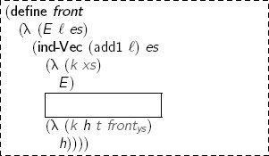

<sup>55</sup>

It would be *E*, but no *E* is available because vecnil is empty.

There is no way to fill this box, but this bad definition of **front** provides no evidence of that fact in the base.

The solution is to change the motive so that the base’s type contains this evidence.

<sup>56</sup>

So the motive isn’t boring, is it?

**ind-Vec** can eliminate *any* Vec, but **front** only works on Vecs whose length has add1 at the top. Because **ind-Vec** is *too powerful* for this task, it must be restricted to rule out the need for a base. This is done by carefully choosing the motive.

<sup>57</sup>

What motive can be used here?

What is the purpose of the motive in **ind-Vec**?

<sup>58</sup>

The motive explains how the type of the **ind-Vec**-expression depends on the two targets.

**mot-front** has a type like any other motive.

(**claim *mot-front***

(Π ((*E U*)

(*k* Nat))

(→ (Vec *E k*)

*U*)))

<sup>59</sup>

This is no different from other uses of **ind-Vec**.

That’s right.

The definition of **mot-front**, however, is quite different.

(**define *mot-front***

(λ (*E*)

(λ (*k es*)

(Π ((*j* Nat))

(→ (**=** Nat *k* (add1 *j*))

*E*)))))

<sup>60</sup>

Please explain that definition.

The argument *k* is a target of **ind-Vec**. Both the base and the step now have two extra arguments: a Nat called *j* and a proof that *k* is (add1 *j*).

In the base, *k* is zero. Thus, there is no such *j*.

<sup>61</sup>

If there were such a *j*, then zero would equal (add1 *j*). But **zero-not-add1** proves that this is impossible.

Exactly.

**zero-not-add1** can be used with **ind-Absurd** to show that no value is needed for the base.

<sup>62</sup>

What about the step?

What is the step’s type?

<sup>63</sup>

The step’s type follows the Law of **ind-Vec**.

(**claim *step-front***

(Π ((*E U*)

(*ℓ* Nat)

(*e E*)

(*es* (Vec *E* *ℓ*)))

(→ (**mot-front** E

*ℓ*

*es*)

(**mot-front** E

(add1 *ℓ*)

(vec:: *e es*)))))

Here is the start of **step-front**. What belongs in the box?

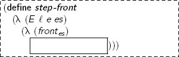

<sup>64</sup>

The box is a

(**mot-front** E

(add1 *ℓ*)

(vec:: *e es*)).

What is the purpose of the expression that goes in the box?

<sup>65</sup>

**front** is not really recursive—like **zerop**, the answer is determined by the top constructor of **ind-Vec**’s target. The answer is *e*, which is the first entry under vec:: in the list.

What is the normal form of the empty box’s type

(**mot-front** E

(add1 *ℓ*)

(vec:: *e es*))?

<sup>66</sup>

The normal form is

(Π ((*j* Nat))

(→ (**=** Nat (add1 *ℓ*) (add1 *j*))

*E*)).

What does this type mean?

<sup>67</sup>

It means that the step builds a function that takes a Nat called *j* and evidence that (add1 *ℓ*) is (add1 *j*), and then produces an *E*. The only *E* here is *e*.

In the base’s type, the motive requires that zero has add1 at the top, so no base is needed. A step, however, can be written because (add1 *ℓ*) does have add1 at the top.

What is the purpose of **step-front**?

<sup>68</sup>

**step-front** finds the value of **front** for non-empty Vecs, which is the first entry in the Vec.

Define **step-front**.

<sup>69</sup>

Because **front** is not recursive, *front<sub>es</sub>* is dim. Similarly, the specific length is not important, because it is not zero. The empty box is filled with a function that ignores its arguments, resulting in *e*.

(**define *step-front***

(λ (*E ℓ e es*)

(λ (*front<sub>es</sub>*)

(λ (*j eq*)

*e*))))

Because the value of **mot-front** is a Π-expression, the **ind-Vec**-expression in **front** has a function type.

<sup>70</sup>

That’s not right. **front** should find the first entry in a Vec, not a function.

The function type found by **mot-front** expects two arguments: a new Nat called *j* and evidence that the length of the Vec is (add1 *j*).

<sup>71</sup>

How does that help?

According to **front**’s type, the Vec’s length already has add1 at the top.

<sup>72</sup>

So the new Nat is *ℓ* because the length of the Vec is (add1 *ℓ*).

Yes.

And, proving that

“(add1 *ℓ*) equals (add1 *ℓ*)”

does not require a complicated argument.

<sup>73</sup>

Right.

Because (same (add1 *ℓ*)) does it.

Now, define **front**.

<sup>74</sup>

Because the **ind-Vec**-expression’s type is a Π-expression, it can be applied to *ℓ* and (same (add1 *ℓ*)).

(**define *front***

(λ (*E ℓ es*)

((**ind-Vec** (add1 *ℓ*) *es*

(**mot-front** E)

(λ (*j eq*)

(**ind-Absurd**

(**zero-not-add1** j eq)

*E*))

(**step-front** E))

*ℓ* (same (add1 *ℓ*)))))

Congratulations!

Being able to design appropriate motives for definitions such as **front** is very important. A similar technique is used to write **drop-last** or **rest** using **ind-Vec**.

<sup>75</sup>

This sounds like a valuable skill.

<sup>76</sup>

The first step is to apply **front** to its arguments.

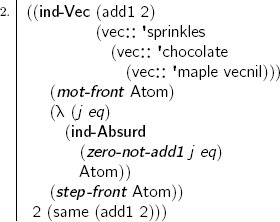

What’s next?

<sup>77</sup>

**ind-Vec**’s targets have add1 and vec:: at the top, so **step-front** is next.

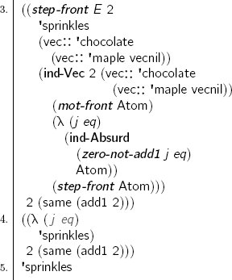

Take a cozy break for *fika* if you feel the need.

<sup>78</sup>

See you in half an hour.

How was the coffee and donuts?

<sup>79</sup>

*Läckert!*

Is every statement true or false?

<sup>80</sup>

Clearly.

“Every statement is true or false.” is called *the Principle of the Excluded Middle*.†

_______________

†Sometimes, the Principle of the Excluded Middle is called the “Law” of the Excluded Middle. It is also sometimes written *tertium non datur*, which means “there is no third choice.”

<sup>81</sup>

Let’s prove it.

Write the statement

“*Every* statement is true or false.”

as a type.

<sup>82</sup>

Statements are types. How can “is false” be written as a type?

If a statement is false, it has no evidence. This can be written as an “if-then” statement.

“*X* is false” is written

(→ *X*

Absurd).

<sup>83</sup>

“Every statement is true or false.” is a Π-expression.

(**claim *pem***

(Π ((*X U*))

(Either *X*

(→ *X*

Absurd))))

There is no evidence for **pem**.

<sup>84</sup>

Why not?

What would count as evidence for **pem**?

<sup>85</sup>

Evidence for **pem** would be a function that determines the truth or falsity of *every statement that can be written as a type.*

Every single statement?

<sup>86</sup>

Every single statement, because Π means “every.”

This would mean that there are no unsolved problems.

<sup>87</sup>

Great! No more problems.

Life would be boring if we had no problems left to solve.

<sup>88</sup>

So **pem** isn’t true, but it can’t possibly be false!

That’s right.

<sup>89</sup>

It’s not true, but it can’t be false?

That’s right. It can’t possibly be false.

Write

“‘Every statement is true or false’ can’t possibly be false.”

as a type.

<sup>90</sup>

In other words,

“ ‘ “Every statement is true or false” is false’ is false.”

(**claim *pem-not-false***

(Π ((*X U*))

(→ (→ (Either *X*

(→ *X*

Absurd))

Absurd)

Absurd)))

That’s right. Now prove **pem-not-false**.

<sup>91</sup>

How?

What counts as evidence for a Π-expression?

<sup>92</sup>

A λ-expression.

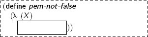

What is the empty box’s type?

<sup>93</sup>

The empty box is an

(→ (→ (Either *X*

(→ *X*

Absurd))

Absurd)

Absurd),

so it should also be filled with a λ-expression.

That’s right.

Continue the proof.

<sup>94</sup>

This new λ-expression accepts evidence that the Principle of the Excluded Middle is false for *X* as its argument.

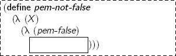

What can be done with *pem-false*?

<sup>95</sup>

*pem-false*’s type has → at the top, so it can be eliminated by applying it. The empty box’s type is Absurd, and *pem-false* would produce evidence of Absurd if it were applied to a suitable argument.

What is the type of suitable arguments?

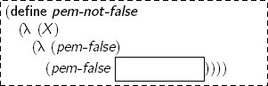

<sup>96</sup>

The boy’s type is

(Either *X*

(→ *X*

Absurd)).

There are two ways to construct one of those.

Is left relevant?

<sup>97</sup>

No, left is not relevant because there is no evidence for *X* available.

What about right?

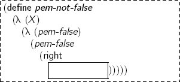

What is the empty box’s type now?

<sup>98</sup>

The box’s type is

(→ *X*

Absurd).

What is evidence for an →?

<sup>99</sup>

A λ-expression. This new box’s type is Absurd.

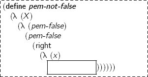

What can be used to make an Absurd?

<sup>100</sup>

*pem-false* can.

Give it a try.

<sup>101</sup>

Again? Okay.

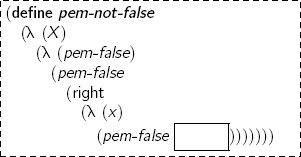

This box’s type is

(Either *X*

(→ *X*

Absurd)).

<sup>102</sup>

Isn’t this getting a bit repetitive?

The difference is that there is now an *X* available.

<sup>103</sup>

This means that left can be used.

(**define *pem-not-false***

(λ (*X*)

(λ (*pem-false*)

(*pem-false*

(right

(λ (*x*)

(*pem-false*

(left *x*))))))))

Nice proof.

<sup>104</sup>

But if the Principle of the Excluded Middle is not false, why isn’t it true?

Very funny.

If **pem** were true, then we would have evidence: a magical total function that solves every problem that we can write as a type.

<sup>105</sup>

So evidence that a statement is not false is less interesting than evidence that it is true?

Exactly.

There are, however, some statements that *are* either true or false. These statements are called *decidable* because there is a function that decides whether they are true or false.

<sup>106</sup>

Can “*X* is decidable” be written as a type?

It certainly can.

(**claim *Dec***

(→ *U*

*U*))

(**define *Dec***

(λ (*X*)

(Either *X*

(→ *X*

Absurd))))

<sup>107</sup>

That looks a lot like **pem**.

Another way to phrase **pem** is

“All statements are decidable.”

<sup>108</sup>

So **pem**’s claim could have been written using **Dec**.

(**claim *pem***

(Π ((*X U*))

(**Dec** X)))

Some statements are decidable, even though not all statements are decidable.

<sup>109</sup>

How about deciding that this has been enough for today?

Sure. Tomorrow, we encounter a decidable statement.

<sup>110</sup>

It’s a good thing there are more donuts.

**Enjoy your donuts**

**you’ll need your energy for tomorrow’s decisions.**

[figure not shown]

Remember **zerop** from chapter 3?

<sup>1</sup>

Refresh my memory.

If *n* is a Nat, then (**zerop** n) is an Atom.

<sup>2</sup>

Which Atom is it?

Good question.

The type

(→ Nat

Atom)

is not particularly specific.

<sup>3</sup>

No, it isn’t. But, based on frame 3:43 on page 80,

(**zerop** n)

is **'**t when *n* is zero, and **'**nil otherwise.

The specific type that describes checking for zero can be written using **Dec**.

(**claim *zero?***

(Π ((*j* Nat))

(**Dec**

(**=** Nat zero *j*))))

<sup>4</sup>

That type says,

“For every Nat *j*, it is decidable whether *j* equals zero.”

What would count as evidence for that statement?

<sup>5</sup>

A function that, given some *j*, decides whether *j* equals zero.

If the value of (**zero?** n) has left at the top, what is tucked under left?

<sup>6</sup>

Evidence that *n* equals zero, because

(**Dec**

(**=** Nat zero *n*))

and

(Either

(**=** Nat zero *n*)

(→ (**=** Nat zero *n*)

Absurd))

are the same type.

If the value of (**zero?** n) has right at the top, what is tucked under right?

<sup>7</sup>

Evidence that *n* is not equal to zero.

In other words, the type of **zero?** says that not only does it determine whether a number is zero, it also constructs evidence that it is the correct choice.

<sup>8</sup>

**zero?** is a function, so it has λ at the top.

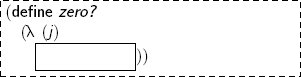

The empty box’s type is

(**Dec**

(**=** Nat zero *j*)).

Should it be filled with left or right?

<sup>9</sup>

That depends on *j*. Because the empty box’s type mentions the target *j*, **ind-Nat** must be used.

What about the motive?

<sup>10</sup>

The motive can be found by abstracting over the target.

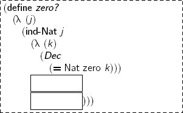

Why not abstract over zero in the base’s type?

<sup>11</sup>

There are two zeros in the base’s type, but only one of them is the target.

What is the base? Its type is

(**Dec**

(**=** Nat zero zero)).

<sup>12</sup>

So,

(left

(same zero))

does the trick.

What about the step?

<sup>13</sup>

The step’s type is

(Π ((*j-1* Nat))

(→ (**Dec**

(**=** Nat zero *j-1*))

(**Dec**

(**=** Nat zero (add1 *j-1*))))).

Is zero ever equal to a Nat with add1 at the top?

<sup>14</sup>

No.

Prove that

“zero is not equal to (add1 *j-1*).”

<sup>15</sup>

The proof is (**zero-not-add1** j-1).

That’s right.

Use this to define the step.

<sup>16</sup>

**zero?** is not really recursive, so *zero?<sub>n-1</sub>* is dim. The proof that (add1 *j-1*) is not equal to zero is tucked under a right because **Dec** is defined to mean Either.

(**define *zero?***

(λ (*j*)

(**ind-Nat** *j*

(λ (*k*)

(**Dec**

(**=** Nat zero *k*)))

(left

(same zero))

(λ (*j-1 zero?<sub>n-1</sub>*)

(right

(**zero-not-add1** j-1))))))

**zero?** is both a *proof* that equality with zero is either true or false and a *function* that decides whether any given Nat is equal to zero.

In fact,

“For *every* two natural numbers *n* and *j*, it is decidable whether *n* equals *j*.”

<sup>17</sup>

That’s a bold claim.

(**claim *nat=?***

(Π ((*n* Nat)

(*j* Nat))

(**Dec**

(**=** Nat *n j*))))

A claim requires a proof.

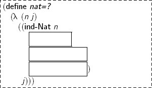

<sup>18</sup>

That’s a strange way to start the proof.

What is the reason that the **ind-Nat**-expression is applied to *j* ?

The definition of **front** uses a more informative motive to make apparent that the base is unnecessary.

<sup>19</sup>

Is **nat=?**’s base also unnecessary?

No, **nat=?** needs a base because it makes sense to apply it to zero as an argument.

But a more informative motive is needed here in order to write the step, or else the almost-proof does not prove a strong enough statement.

<sup>20</sup>

Please point out where this is necessary.

Gladly.

What is the motive’s type?

<sup>21</sup>

Every motive used with **ind-Nat** has the same type.

(**claim *mot-nat=?***

(→ Nat

*U*))

The more informative motive, read as a statement, says

“For every Nat *j*, it is decidable whether *j* is equal to the target.”

Write this as a function from the target to a type.

<sup>22</sup>

The *every* means that there is a Π, and the target is the argument to the motive.

(**define *mot-nat=?***

(λ (*k*)

(Π ((*j* Nat))

(**Dec**

(**=** Nat *k j*)))))

Compare **mot-nat=?** to **mot-front** in frame 15:60 on page 330.

<sup>23</sup>

Both of them give Π-expressions, so the base and step accept arguments.

These arguments, however, serve different purposes.

The extra arguments in **front** are used to make the types more specific to rule out the base. On the other hand, the extra argument in **nat=?** is used to make the type more general so that the almost-proofs can decide equalities with *every* Nat, instead of only the second argument to **nat=?**.

<sup>24</sup>

Neither motive is found by just abstracting over some constant, though.

Sometimes, the “motive” is more complicated than just “what” the base is.

Speaking of the base, what is its type?

<sup>25</sup>

The base is a

(Π ((*j* Nat))

(**Dec**

(**=** Nat zero *j*))).

What has that type?

<sup>26</sup>

**zero?** has that type.

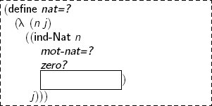

The step is still an empty box. What is its type?

<sup>27</sup>

For **ind-Nat**, the type of the step is found using the motive.

(**claim *step-nat=?***

(Π ((*n-1* Nat))

(→ (**mot-nat=?** n-1)

(**mot-nat=?** (add1 *n-1*)))))

The types of the step and the motive are determined by the Law of **ind-Nat**. Their definitions, however, may both require insight.

Define **step-nat=?**.

<sup>28</sup>

Here’s a start.

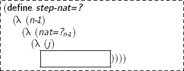

**step-nat=?**’s type has a Π and an →, but that definition has three λs.

Why is the innermost λ present?

<sup>29</sup>

The innermost λ-expression is there because

(**mot-nat=?** (add1 *n-1*))

and

(Π ((*j* Nat))

(**Dec**

(**=** Nat (add1 *n-1*) *j*)))

are the same type.

Now it is time to decide whether

(add1 *n-1*) equals *j*.

<sup>30</sup>

If *j* is zero, then they are certainly not equal.

Checking whether *j* is zero requires an eliminator.

<sup>31</sup>

**ind-Nat** is the only eliminator for Nat that allows the type to depend on the target, and *j* is in the type.

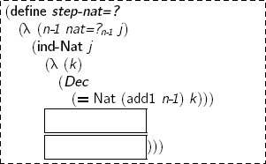

In this definition, the base is much easier than the step. What is the base’s type?

<sup>32</sup>

The base’s type is

(**Dec**

(**=** Nat (add1 *n-1*) zero)).

The base has right at the top because (add1 *n-1*) certainly does not equal zero.

Prove it.

<sup>33</sup>

Prove what?

Prove that

“(add1 *n-1*) does not equal zero.”

<sup>34</sup>

Again?

**zero-not-add1** is not a proof that

“(add1 *n-1*) does not equal zero.”

<sup>35</sup>

Ah.

(**claim *add1-not-zero***

(Π ((*n* Nat))

(→ (**=** Nat (add1 *n*) zero)

Absurd)))

(**define *add1-not-zero***

(λ (*n*)

(**use-Nat=** (add1 *n*) zero)))

What is the base?

<sup>36</sup>

The base has right at the top, and uses **add1-not-zero**.

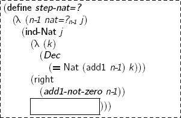

What is the step’s type?

<sup>37</sup>

The step is a

(Π ((*j-1* Nat))

(→ (**Dec**

(**=** Nat (add1 *n-1*) *j-1*))

(**Dec**

(**=** Nat (add1 *n-1*) (add1 *j-1*))))).

If **mot-nat=?** didn’t produce a Π-expression, we would be unable to write the step.

<sup>38</sup>

Why is that?

In order to decide whether

(add1 *n-1*) equals (add1 *j-1*),

is it useful to know whether

(add1 *n-1*) equals *j-1*?

<sup>39</sup>

4 does not equal 3, but 4 certainly equals (add1 3).

On the other hand, 4 does not equal 9, but 4 also does not equal (add1 9).

This means that the second argument to this step is dim.

<sup>40</sup>

How can the decision be made?

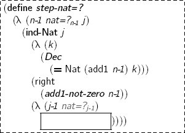

*nat=?<sub>n-1</sub>* is able to decide whether *n-1* is equal to *any* Nat.

<sup>41</sup>

And that is the reason why **mot-nat=?** must have a Π-expression in its body. Otherwise, *nat=?<sub>n-1</sub>* would just be a statement about *j* that is unrelated to (add1 *j-1*).

What type does

(*nat=?<sub>n-1</sub> j-1*)

have?

<sup>42</sup>

It is a

(**Dec**

(**=** Nat *n-1 j-1*))